# Wielowymiarowa Analiza Rezerwacji Hotelowych

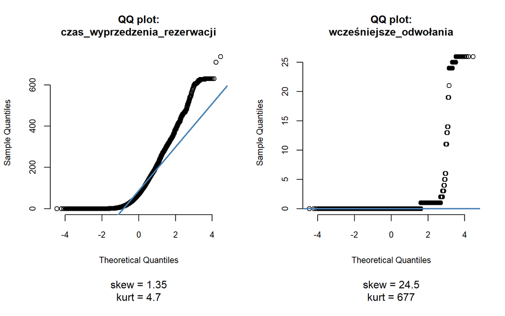

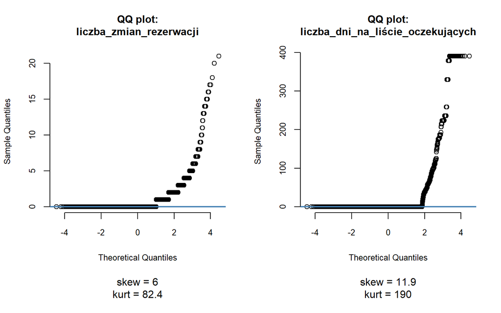

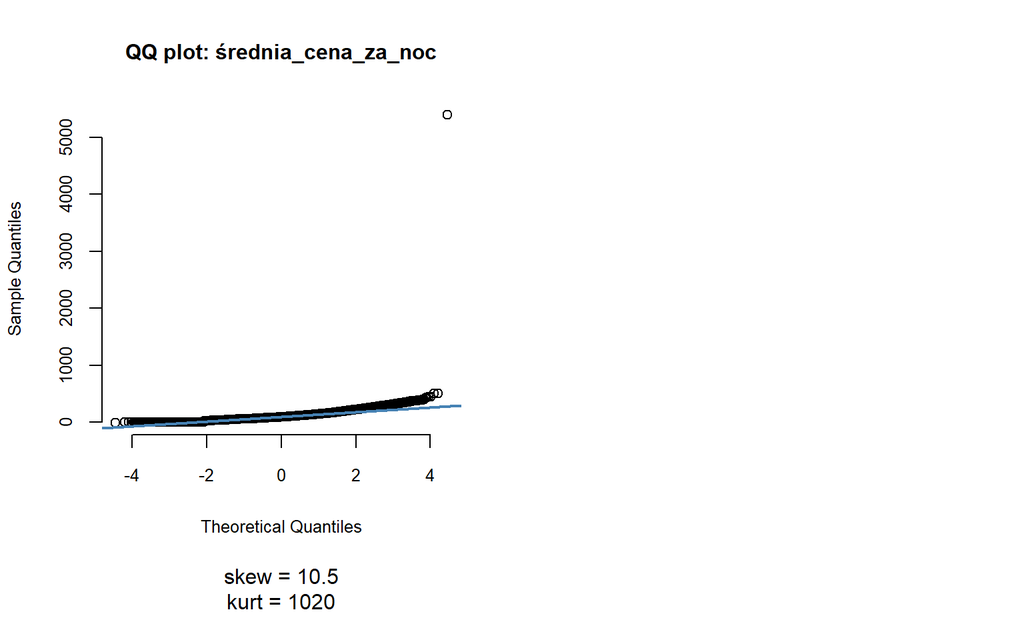

| Zmienna | Skewness | Kurtosis | Interpretacja |
| --- | --- | --- | --- |
| wcześniejsze_rezerwacje_nieodwołane | 23.5 | 770 | Skrajnie dodatnio skośny rozkład z bardzo ciężkim ogonem, wskazujący na pojedyncze wartości ekstremalne. |
| liczba_specjalnych_próśb | 1.35 | 4.49 | Lekko dodatnio skośny rozkład, z niewielkim wpływem outlierów. Rozkład umiarkowanie spiczasty. |
| liczba_nocy_weekendowych | 1.38 | 10.2 | Dodatnia skośność z wyraźnie ciężkimi ogonami. Pojedyncze rezerwacje o dużej liczbie nocy wpływają na spiczastość rozkładu. |
| liczba_nocy_tygodniowych | 2.86 | 27.3 | Wyraźna dodatnia skośność i ciężki ogon, zmienna zawiera istotne outliery. |
| liczba_dorosłych | 18.3 | 1360 | Bardzo duża dodatnia skośność i ekstremalnie spiczasty rozkład. Skrajne wartości znacząco wpływają na średnią. |
| liczba_dzieci | 4.11 | 21.7 | Znacząca dodatnia skośność i ciężkie ogony, pojedyncze wartości odstające. |
| liczba_niemowląt | 24.6 | 1640 | Skrajnie dodatnio skośny i ekstremalnie spiczasty rozkład. Większość wartości to 0 lub 1, z pojedynczymi dużymi wartościami. |
| wymagane_miejsca_parkingowe | 4.16 | 33 | Dodatnia skośność i ciężkie ogony; pojedyncze rezerwacje wymagają dużo miejsc parkingowych. |
| czas_wyprzedzenia_rezerwacji | 1.35 | 4.7 | Lekko dodatnio skośny rozkład, umiarkowanie spiczasty. Rozkład jest stosunkowo zbliżony do normalnego, ale z kilkoma outlierami. |
| wcześniejsze_odwołania | 24.5 | 677 | Skrajna dodatnia skośność i spiczystość; pojedyncze rezerwacje z wieloma odwołaniami. |

[output cut: 3 more lines]

Analiza rozkładów zmiennych ilościowych przy użyciu **boxplotów**, a także wartości **skośności** *(skewness)* i **kurtozy** *(kurtosis)* pozwoliła zidentyfikować zmienne z odchyleniami i wartościami odstającymi. Wysokie wartości skewness wskazują na asymetrię rozkładu, a wysokie wartości kurtosis – na spiczastość i ciężkie ogony. W takich przypadkach lepszą miarą tendencji centralnej niż średnia jest mediana. Szczegółowe interpretacje dla każdej zmiennej znajdują się w powyższej tabeli.

### 2.5.3. Wielowymiarowa analiza odchyleń względem zmiennej objaśnianej

W kolejnym kroku przeprowadzono wielowymiarową analizę odchyleń z wykorzystaniem relacji między zmienną objaśnianą *odwołanie rezerwacji* a zmiennymi objaśniającymi.

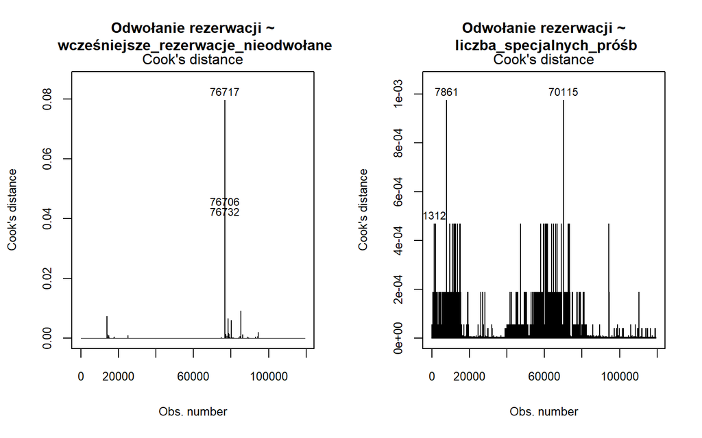

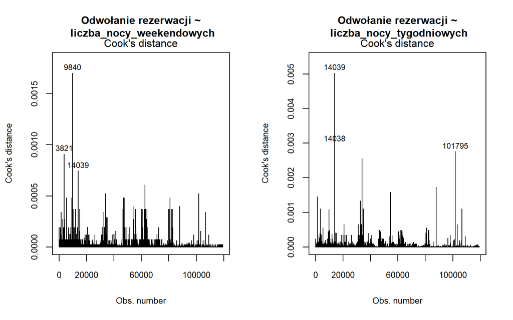

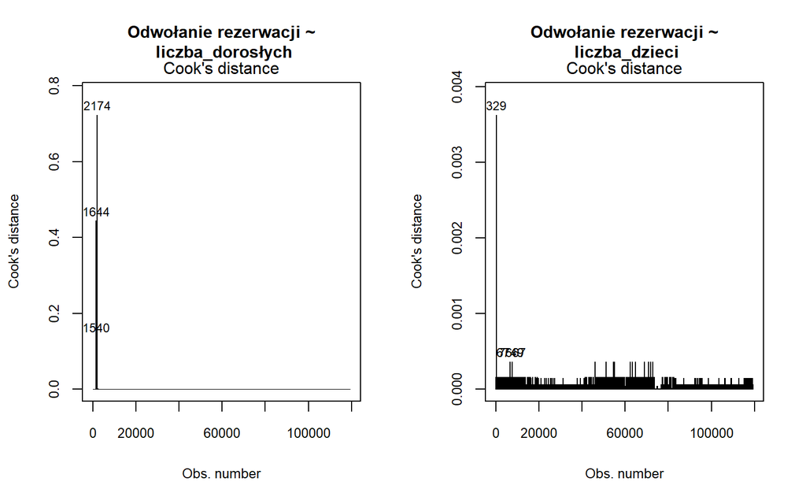

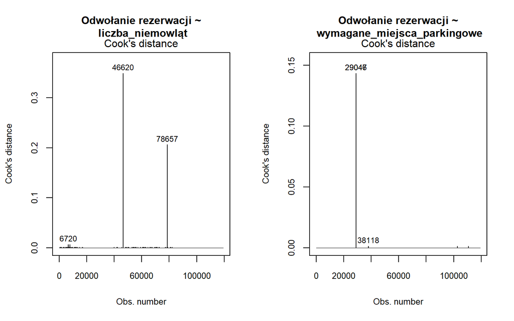

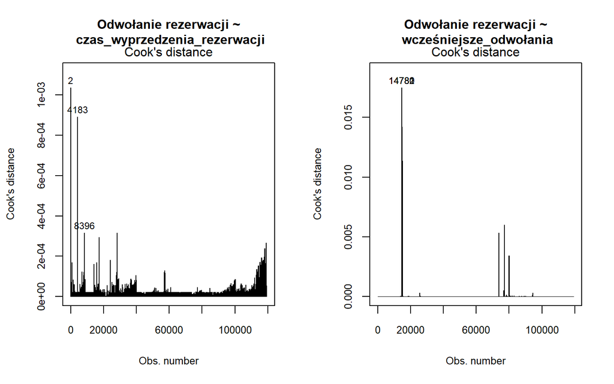

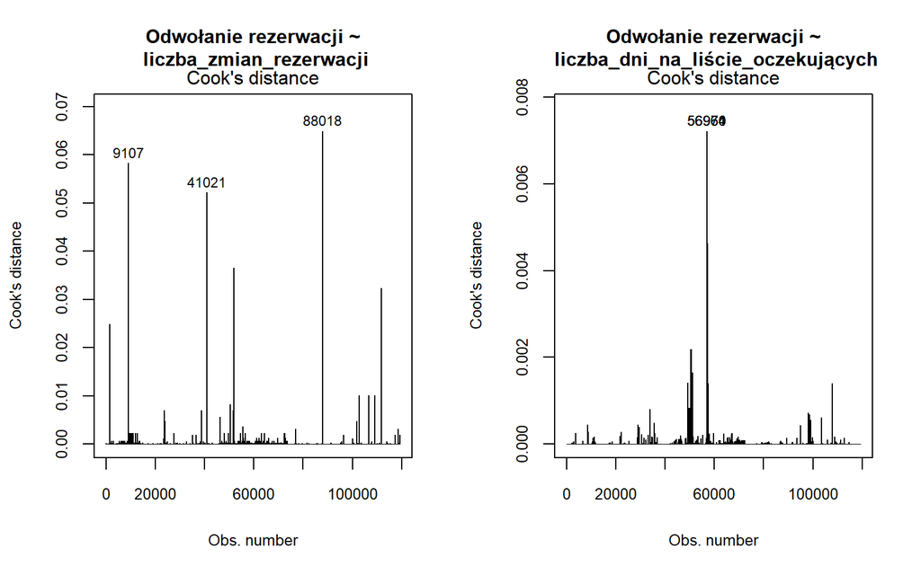

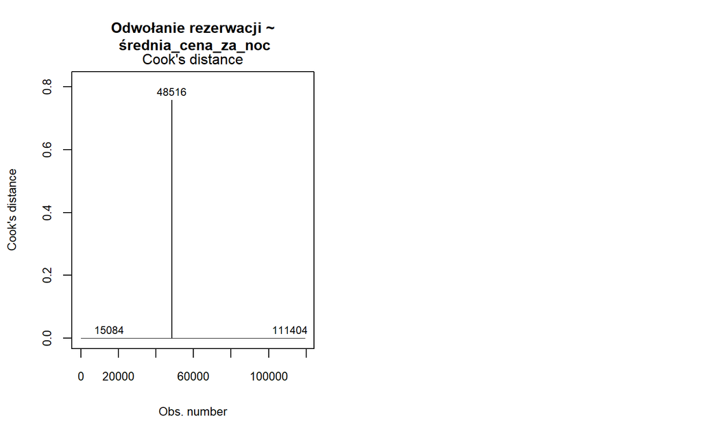

# 3. Czyszczenie danych

## 3.1. Obsługa braków wartości

### 3.1.1. Analiza występowania braków danych

Poniżej przeprowdzono dokładną analizę braków danych w zmiennych *liczba_dzieci*, *agent_rezerwacji* oraz *firma*, mającą na celu wskazanie dalszego postępowania.

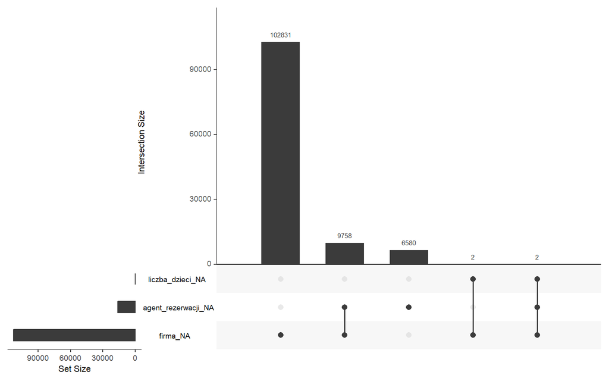

W celu dokładniejszej analizy utworzono **wykres UpSet**, który prezentuje współwystępowanie braków między zmiennymi. Wynika z niego, że:

- dla zmiennej *liczba_dzieci* wszystkie 4 braki występują współzależnie: 2 braki z wartościami NA w zmiennej firma oraz 2 braki z brakami we wszystkich dwóch pozostałych analizowanych zmiennych;
- dla zmiennej *agent_rezerwacji* ok. 9,8 tys. braków (ok. 59.72%) występuje wspólnie z brakami w zmiennej firma, a 2 braki, jak już ustalono, wraz z brakami w pozostałych zmiennych. Natomiast blisko 6,6 tys. braków (ok. 40.27%) występuje niezależnie;
- w zmiennej *firma*, poza wskazanymi zależnościami braków, zdecydowana większość wartości NA (ok. 91.33%) występuje niezależnie.

*Test MCAR*

*H0: dane są MCAR - braki danych są całkowicie losowe*  
*HA: dane nie są MCAR - braki danych są zależne od danych*

| statistic | df | p.value | missing.patterns |
| --- | --- | --- | --- |
| 633.624 | 6 | 0 | 6 |

**Test Little’a** dla braków danych wykazał istotność statystyczną (χ² = 633.62, df = 6, p < 0.001), co pozwala odrzucić hipotezę zerową o losowym występowaniu braków (MCAR). Oznacza to, że brakujące wartości w danych nie występują całkowicie losowo i mogą zależeć od innych zmiennych. W związku z tym dalsza analiza wymaga zastosowania odpowiednich metod radzenia sobie z brakami danych, takich jak imputacja lub modele uwzględniające ich obecność.

### 3.1.2. Usuwanie braków danych

Na podstawie powyższej analizy wysunięto następujące wnioski:

- **zmienna** *lista_dzieci*

Wartości NA występujące w tej zmiennej stanowią marginalny odsetek obserwacji (0,003%). Ponadto, współwystępują one z brakami w pozostałych analizowanych pod kądtem braków zmiennych. Zaleca się wobec tego usunięcie rekordów z brakami, bez stosowania imputacji.

- **zmienna** *agent_rezerwacji*

Brakujące wartości zmiennej agent_rezerwacji stanowią 13,69% wartości tej zmiennej i są one w 59,72% współzależne z brakami w zmiennej firma. Wobec tego, zaleca się zastosowanie prostej imputacji tych wartości średnią lub medianą wartości tej zmiennej, bądź uzupełnianie jej poprzez wielokrotną imputację, np. przy pomocy pakietu “mice”. Z uwagi jednak na charakter i specyfikę wartości zmiennej agent_rezerwacji, tj. ID agencji podróży, która dokonała rezerwacji, zasadnym uznano usunięcie tej zmiennej z dalszej analicy.

- **zmienna** *firma*

Braki w zmiennej firma, przez wzgląd, iż stanowią ponad 94% wszystkich wartości tej zmiennej, odbierają jej wartość informacyjną, wobec czego należy usunąć tę zmienną.

| Zmienna | Liczba_NA |
| --- | --- |
| typ_hotelu | 0 |
| odwołanie_rezerwacji | 0 |
| czas_wyprzedzenia_rezerwacji | 0 |
| rok_przyjazdu | 0 |
| miesiąc_przyjazdu | 0 |
| numer_tygodnia_przyjazdu | 0 |
| dzień_przyjazdu_w_miesiącu | 0 |
| liczba_nocy_weekendowych | 0 |
| liczba_nocy_tygodniowych | 0 |
| liczba_dorosłych | 0 |

[output cut: 24 more lines]

Liczba obserwacji w zbiorze po usunięciu braków w zmiennej *liczba_dzieci*: **119386**

Liczba zmiennych w zbiorze po usunięciu zmiennej *agent_rezerwacji* oraz *firma*: **34**

## 3.2. Obsługa obserwacji odstających

W celu redukcji wartości odtsających zdecydowano się na zastosowanie podejścia mieszanego. Na podstawie analizy boxplotów, miar skośności i kurtozy zidentyfikowano zmienne charakteryzujące się silnymi odchyleniami od symetrii oraz obecnością wartości ekstremalnych. Dodatkowo wykorzystano analizę odległości Cooka, która pozwoliła wskazać obserwacje silnie wpływowe, mogące w istotny sposób zakłócić dalszą analizę głównych składowych oraz analizę skupień, znanych z wysokiej wrażliwości na obserwacje odstające.

### 3.2.1. Usunięcie wartości skrajnych

Aby ograniczyć wpływ obserwacji odstających na wariancję i odległości między obiektami, przed przeprowadzeniem analiz usunięto najbardziej wpływowe obserwacje, wyznaczone na podstawie statystyki Cooka, przyjmując próg $4/n$.

W konsekwencji usunięto **2725** obserwacji (**2.28%**) o najwyższym wpływie na dopasowanie modelu.

### 3.2.2. Winsoryzacja

W kolejnym etapie rozważono sposób ograniczenia wpływu wartości odstających w zmiennych ilościowych o wysokiej skośności (skewness > 1). W dostosowywaniu winsonizacji uwzględniono również charakter zmiennych oraz ich potencjalny wpływ na analizę głównych składowych (PCA) oraz analizę skupień.

Dla zmiennych o szerokim zakresie wartości i wyraźnych wartościach skrajnych (takich jak *średnia_cena_za_noc* czy *liczba_dni_na_liście_oczekujących*), które mogłyby silnie wpływać na wariancję i odległości pomiędzy obserwacjami, zastosowano winsoryzację opartą na percentylach 1% i 99%. Wybór tej metody był uzasadniony tym, że reguła IQR prowadziła do modyfikacji większego odsetka danych (ok. 3.18% w przypadku zmiennej o najwyższej skośności spośród wskazanych - tj. *średnia_cena_za_noc* (skew = 10,5)), co przy tak dużym zbiorze danych mogłoby prowadzić do nadmiernego wygładzenia rozkładów.

Metoda percentylowa pozwoliła ograniczyć wpływ najbardziej skrajnych obserwacji (ok. 0.98% danych dla zmiennej o najwyższym skewness), zachowując jednocześnie strukturę zmienności istotną dla dalszych analiz wielowymiarowych. Pozwoliło to zmniejszyć wpływ ekstremów bez utraty istotnych obserwacji oraz uniknąć nadmierną modyfikację danych, charakterystyczną dla reguły IQR w przypadku rozkładów silnie skośnych.

### 3.2.3. Ograniczenie zmiennych “z góry”

Zmienne takie, jak *liczba_niemowląt*, *liczba_zmian_rezerwacji*, *wcześniejsze_rezerwacje_nieodwołane* i *wcześniejsze_odwołania*, w których zdecydowana większość obserwacji przyjmowała wartość 0, nie zostały poddane klasycznej winsoryzacji percentylowej, ponieważ mogłoby to prowadzić do utraty informacji lub powstania wartości NA. W ich przypadku zastosowano jedynie kontrolowane ograniczenie najwyższych wartości, co pozwoliło zmniejszyć wpływ pojedynczych obserwacji skrajnych na analizę PCA i skupień, bez zmiany interpretacji tych zmiennych.

### 3.2.5. Podsumowanie wartości zmiennych po przekształceniach

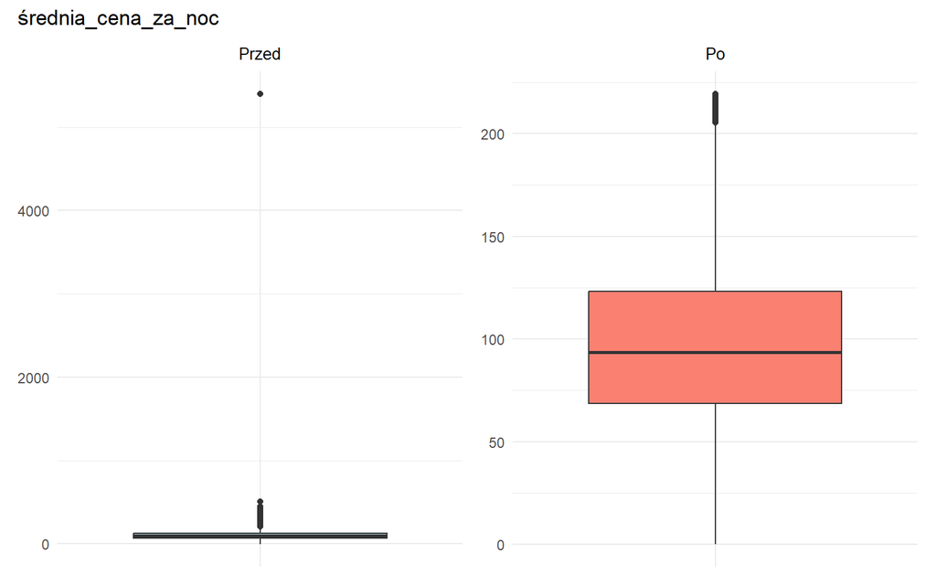

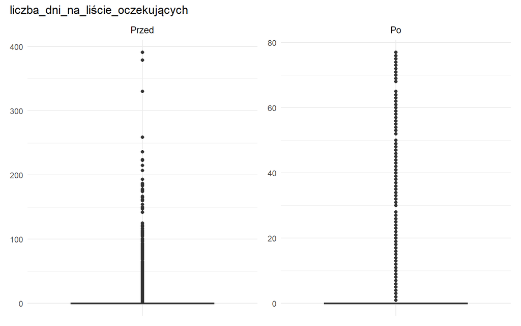

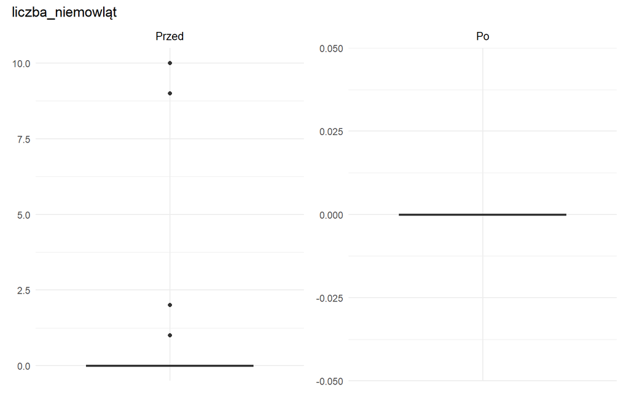

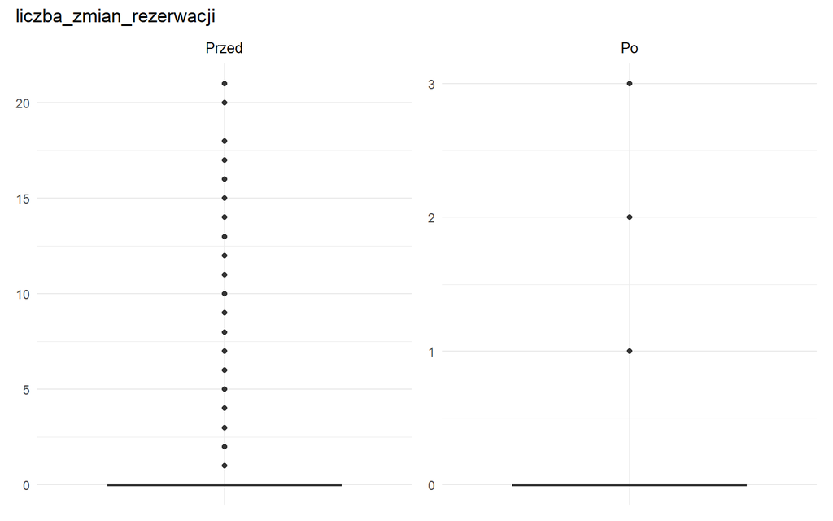

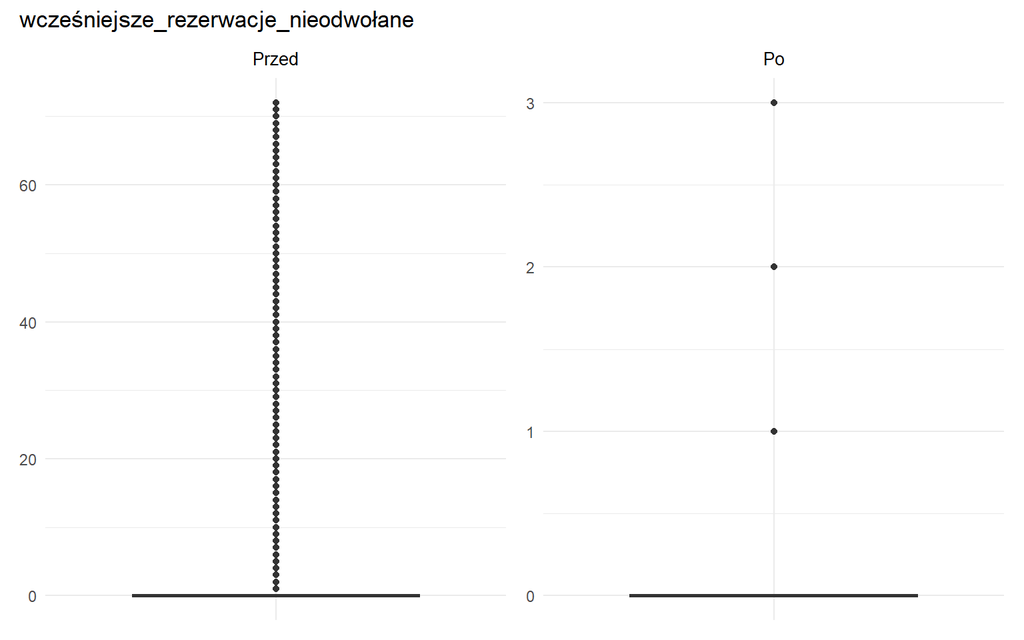

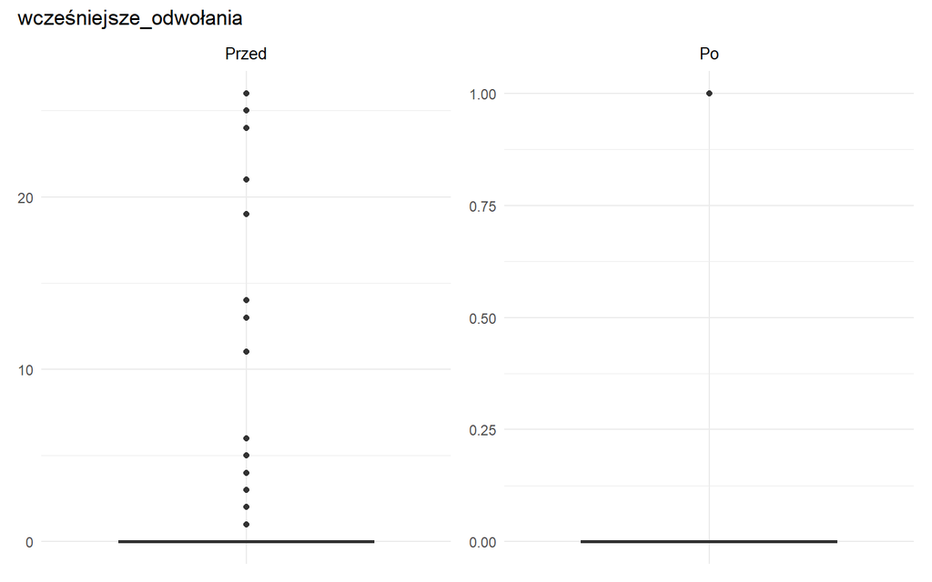

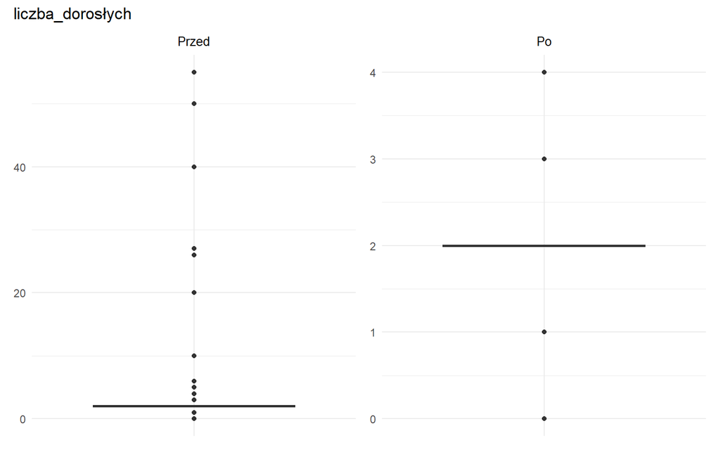

**INTERPRETACJE:**

*1. Średnia cena za noc*  
Na pierwszym wykresie widać, jak ekstremalne wartości odstające przekraczające 5000 jednostek całkowicie zniekształciły skalę i uniemożliwiły analizę rozkładu. Po usunięciu tych błędnych lub nietypowych rekordów, skala osi Y uległa znacznemu zawężeniu, co pozwoliło na wyraźne przedstawienie struktury cenowej z medianą oscylującą w okolicach 95 jednostek. Dzięki temu zabiegowi dane stały się czytelne, ujawniając, że większość cen mieści się w przedziale od 70 do 125, podczas gdy pozostałe wartości powyżej 200 stanowią już tylko nieliczne i łatwe do zidentyfikowania punkty.

*2. Liczba dni na liście oczekujących*  
Ponownie obsługa outlierów pozwoliła na ograniczenie osi Y poprawiając czytelność wyników. Porównanie wykresów pokazuje, że przed obróbką dane były silnie obciążone ekstremalnymi wartościami odstającymi, sięgającymi blisko 400 dni, co spłaszczało główną część rozkładu do poziomu zerowego. Poprzez usunięcie tych najbardziej oddalonych punktów i zawężenie skali osi Y do 80 jednostek, udało się uzyskać znacznie większą szczegółowość danych, choć sam kształt pudełka nadal pozostaje minimalny ze względu na dużą koncentrację obserwacji przy wartościach bliskich zeru. Taka transformacja pozwala na lepszą identyfikację “łagodniejszych” wartości odstających i pokazuje, że po odrzuceniu ekstremów większość pozostałych incydentalnych oczekiwań mieści się w zakresie do około 75 dni.

*3. Liczba niemowląt*  
Pierwotny wykres wskazywał na obecność nierealistycznych wartości odstających, sięgających nawet 10 niemowląt, co w kontekście rezerwacji hotelowej jest niemal niemożliwe. Po procesie czyszczenia zmienna ta została sprowadzona do stałej wartości równej zero, co widać na wykresie „po” jako pojedynczą, poziomą linię. Oznacza to, że po odrzuceniu błędnych lub ekstremalnie rzadkich rekordów, cecha ta przestała wykazywać zmienność w analizowanym zbiorze danych.

*6. Wcześniejsze odwołania*  
Proces czyszczenia danych wyeliminował ekstremalne wartości odstające sięgające 25 incydentów, które całkowicie zniekształcały obraz statystyczny grupy. Po zawężeniu skali do zakresu 0–1, wykres stał się czytelny i wykazał, że po usunięciu anomalii typowa aktywność w tym obszarze ogranicza się do pojedynczych przypadków. Taka korekta pozwoliła przejść od chaotycznego zbioru punktów do klarownej prezentacji, w której jedynym istotnym punktem poza zerem jest wartość 1.

*7. Liczba dorosłych*  
W wyniku czyszczenia danych usunięto skrajne i nierealistyczne obserwacje odstające, które przed korektą osiągały nawet 50–60 osób w ramach pojedynczej rezerwacji. Po ograniczeniu zakresu wartości do przedziału 0–4 wykres stał się czytelny i jednoznacznie pokazał, że najczęściej występują rezerwacje obejmujące 2 osoby dorosłe, co odpowiada medianie analizowanego zbioru. Eliminacja anomalii pozwoliła na uzyskanie spójnego i wiarygodnego rozkładu, odzwierciedlającego naturalne zróżnicowanie liczebności grup podróżnych, które mieści się w granicach od 0 do 4 osób i było wcześniej całkowicie zaburzone przez błędy danych.

| zmienna | min | max | średnia | sd | Q1 | mediana | Q3 |
| --- | --- | --- | --- | --- | --- | --- | --- |
| wcześniejsze_rezerwacje_nieodwołane | 0 | 72 | 0.14 | 1.5 | 0 | 0 | 0 |
| liczba_specjalnych_próśb | 0 | 5 | 0.57 | 0.79 | 0 | 0 | 1 |
| liczba_nocy_weekendowych | 0 | 19 | 0.93 | 1 | 0 | 1 | 2 |
| liczba_nocy_tygodniowych | 0 | 50 | 2.5 | 1.91 | 1 | 2 | 3 |
| liczba_dorosłych | 0 | 55 | 1.86 | 0.58 | 2 | 2 | 2 |
| liczba_dzieci | 0 | 10 | 0.1 | 0.4 | 0 | 0 | 0 |
| liczba_niemowląt | 0 | 10 | 0.01 | 0.1 | 0 | 0 | 0 |
| wymagane_miejsca_parkingowe | 0 | 8 | 0.06 | 0.25 | 0 | 0 | 0 |
| czas_wyprzedzenia_rezerwacji | 0 | 737 | 104.01 | 106.86 | 18 | 69 | 160 |
| wcześniejsze_odwołania | 0 | 26 | 0.09 | 0.84 | 0 | 0 | 0 |

[output cut: 3 more lines]

| zmienna | min | max | średnia | sd | Q1 | mediana | Q3 |
| --- | --- | --- | --- | --- | --- | --- | --- |
| wcześniejsze_rezerwacje_nieodwołane | 0 | 3 | 0.06 | 0.38 | 0 | 0 | 0 |
| liczba_specjalnych_próśb | 0 | 5 | 0.57 | 0.79 | 0 | 0 | 1 |
| liczba_nocy_weekendowych | 0 | 19 | 0.92 | 1 | 0 | 1 | 2 |
| liczba_nocy_tygodniowych | 0 | 50 | 2.49 | 1.91 | 1 | 2 | 3 |
| liczba_dorosłych | 0 | 4 | 1.85 | 0.49 | 2 | 2 | 2 |
| liczba_dzieci | 0 | 10 | 0.09 | 0.37 | 0 | 0 | 0 |
| liczba_niemowląt | 0 | 0 | 0 | 0 | 0 | 0 | 0 |
| wymagane_miejsca_parkingowe | 0 | 8 | 0.06 | 0.24 | 0 | 0 | 0 |
| czas_wyprzedzenia_rezerwacji | 0 | 737 | 104.56 | 107.36 | 18 | 70 | 161 |
| wcześniejsze_odwołania | 0 | 1 | 0.05 | 0.23 | 0 | 0 | 0 |

[output cut: 3 more lines]

Powyższe tabele prezentują **porównanie statystyk opisowych zmiennych ilościowych przed i po ich przekształceniu**. W pierwszym kroku wyświetlana jest tabela zawierająca statystyki dla danych przed czyszczeniem. Następnie dla zbioru bez outlierów obliczane są podstawowe miary statystyczne. Zaprezentowano je w drugiej tabeli jako dane po przetworzeniu. Dodatkowo w tabeli końcowej wizualnie wyróżnione zostają wiersze odpowiadające zmiennym, które uległy zmianie podczas procesu czyszczenia danych.

|  | skew_przed | skew_po | poprawa_p.% |
| --- | --- | --- | --- |
| wcześniejsze_rezerwacje_nieodwołane | 23.54 | 6.8 | 16.74 |
| liczba_specjalnych_próśb | 1.35 | 1.35 | 0 |
| liczba_nocy_weekendowych | 1.38 | 1.4 | -0.02000000000000002 |
| liczba_nocy_tygodniowych | 2.86 | 2.91 | -0.05000000000000027 |
| liczba_dorosłych | 18.32 | -0.51 | 17.81 |
| liczba_dzieci | 4.11 | 4.45 | -0.3399999999999999 |
| liczba_niemowląt | 24.65 |  |  |
| wymagane_miejsca_parkingowe | 4.16 | 4.2 | -0.04000000000000004 |
| czas_wyprzedzenia_rezerwacji | 1.35 | 1.34 | 0.01000000000000001 |
| wcześniejsze_odwołania | 24.46 | 3.92 | 20.54 |

[output cut: 3 more lines]

Powyższa tabela porównująca **skośność zmiennych ilościowych przed i po usunięciu wartości odstających** oblicza dla każdej zmiennej skośność w oryginalnym zbiorze i w oczyszczonym. Następnie wylicza różnicę w wartościach bezwzględnych, pokazując, jak bardzo rozkład zbliżył się do symetrii. Wyniki wyświetlano w formie tabeli, w której wyróżniono w jakim procencie uległ poprawie parametr skośności po edycji danych.

# 4. Obróbka zmiennych

## 4.1. Tworzenie nowych zmiennych

Do zbioru dodano nową zmienną - **zmiana_pokoju**, która sprawdza, czy rodzaj przydzielonego pokoju różnił się od pokoju pierwotnie zarezerwowanego przez klienta. Przyjmuje następujące wartości:

- 1 (rodzaj pokoju zarezerwowanego różni się od przydzielonego)
- 0 (rodzaj pokoju pozostał bez zmian)

Połączono także zmienne *liczba_nocy_weekendowych* oraz *liczba_nocy_tygodniowych* w celu utworzenia zmiennej o większej sile informacyjnej - **liczba_nocy**, opisującej łączną długość pobytu.

W podobnym celu powstała zmienna **liczba_osób** charakteryzująca łączną liczbę gości, utworzoną ze zmeinnych: *liczba_dorosłych*, *liczba_dzieci* i *liczba_niemowląt*.

| zmienna | min | max | średnia | sd | Q1 | mediana | Q3 |
| --- | --- | --- | --- | --- | --- | --- | --- |
| zmiana_pokoju | 0 | 1 | 0.13 | 0.33 | 0 | 0 | 0 |
| liczba_nocy | 0 | 69 | 3.41 | 2.55 | 2 | 3 | 4 |
| liczba_osób | 0 | 12 | 1.94 | 0.62 | 2 | 2 | 2 |

## 4.2. Usuwanie zmiennych

Ze zbioru danych wykluczono zmienne, które ze względu na konieczność ochrony danch osobowych klientów, utowrzono sztucznie, a które uznano za nieistotne informacyjnie przy analizie głównych składowych (PCA) oraz analizie skupień.

Pominięto również wybrane, nie niosące istotnej wartości informacyjnej zmienne czasowe oraz zmienne opisujące końcowy status rezerwacji. Uzasadnia się to faktem, iż zmienne te odnoszą się do zdarzeń, które nastąpiły po dokonaniu rezerwacji, a co za tym idzie - nie opisują one sytuacji klienta w momencie podejmowania decyzji, co mogłyby zniekształcać wyniki przeprowadzanych analiz.

Dodatkowo, usunięto zmienną *kraj_pochodzenia*, która charakteryzuje się bardzo dużą liczbą kategorii. Jej uwzględnienie w analizie mogłoby proawdzić do nadmiernego zwiększenia liczby zmiennych i utrudniania interpretacji wyników.

Usunięte zmienne to:

- **imię_i_nazwisko**, **adres_email**, **numer_telefonu**, **numer_karty_kredytowej** – zmienne sztuczne, nieistotne analitycznie,
- **dzień_przyjazdu_w_miesiącu**, **rok_przyjazdu** – zmienne czasowe, nadmiarowe,
- **data_statusu_rezerwacji** – zmienna opisująca stan rezerwacji po jej realizacji,
- **kraj_pochodzenia** – zmienna o bardzo dużej liczbie kategorii.

We wcześniejszych etapach analizy usunięto także zmienne **firma** oraz **agent_rezerwacji** ze względu na wsytępowanie wartości NA oraz nie wnoszenie istotnych informacji do analizy (zmienne bez znaczenia liczbowego, zawierające numery ID firm oraz agencji rezerwujących pokoje).

W wyniku dodania nowych zmiennych, które scalają informacje z poszczególnych z nich, wyklucza się ze zbioru zmienne: **rodzaj_zarezerwowanego_pokoju**, **rodzaj_przydzielonego_pokoju**, **liczba_nocy_weekendowych**, **liczba_nocy_tygodniowych**, **liczba_dorosłych**, **liczba_dzieci** i **liczba_niemowląt**.

## 4.3. Standaryzacja i normalizacja

Zmienne ilościowe zostały poddane **standaryzacji metodą Z-score** w celu zapewnienia porównywalności skal oraz równoważnego wpływu zmiennych na wyniki wybranych metod analizy (PCA oraz analiza skupień).

Metoda ta została wybrana, ponieważ analiza głównych składowych i analiza skupień są wrażliwe na różnice skali zmiennych, a standaryzacja pozwala wyrównać wpływ każdej zmiennej na obliczenia odległości i wariancji, bez konieczności zakładania normalności rozkładu danych.  
Nie zdecydowano się natomiast zastosować normalizacji “min-max” (unitaryzacji) lub przekształcenia ilorazowego, gdyż mogłyby niepotrzebnie zmieniać strukturę danych (np. zniekształcać odległości między punktami ujednolicając wpływ zmiennych na odległość), którym porównywalność zapewniła standaryzacja Z-score.

Finalny zbiór po obróbce zawiera **116661** obserwacji i **22** zmiennych.

# 5. ZASTOSOWANIE METOD WIELOWYMIAROWYCH

## 5.1. PCA – Analiza głównych składowych

W celu redukcji wymiarowości i zbadania struktury danych ilościowych w zbiorze, zastosowano **analizę głównych składowych** *(PCA – Principal Component Analysis)*. Jest to metoda statystyczna, która przekształca oryginalne zmienne w nowe, nieskorelowane czynniki, zwane *składowymi głównymi*. Składowe te są uporządkowane na podstawie malejącego udziału objaśniania całkowitej wariancji danych, co pozwala na wydobycie z nich najbardziej istotnych informacji przy użyciu mniejszej liczby wymiarów.

W kolejnych krokach przeprowadzono:

1. **Analizę założeń PCA**, opartą o ocenę korelacji między zmiennymi, test Bartletta oraz kryterium KMO,
2. **Dobór liczby składowych** z wykorzystaniem kryterium procentu skumulowanej wariancji, kryterium Keisera oraz kryterium Catella (wykresu osypiska),
3. **Interpretację wyników** – przedstawiono ładunki czynnikowe ilustrujące wkład zmiennych w poszczególne wymiary, wizualizację korelacji zmiennych ze składowymi głównymi i wykres udziału zmienności objaśnianej przez składowe (cos²).

Ze względu na dużą liczbę obserwacji (116 661), aby uniknąć overplottingu, zrezygnowano z wizualizacji współrzędnych obserwacji w przestrzeni głównych składowych oraz biplotu.

Do analizy włączono **10 zmiennych ilościowych**, wybranych z pierwotnego zbioru zawierającego 22 zmiennych. Pozostałe zmienne, ze względu na charakter jakościowy, nie zostały uwzględnione w procedurze PCA.

### 5.1.1. Sprawdzenie założeń analizy PCA

*1) Macierz korelacji*

W tym kroku ponownie sprawdzono wzajemne powiązania zmiennych ilościowych, tym razem na danych finalnych, po obróbce zmiennych.

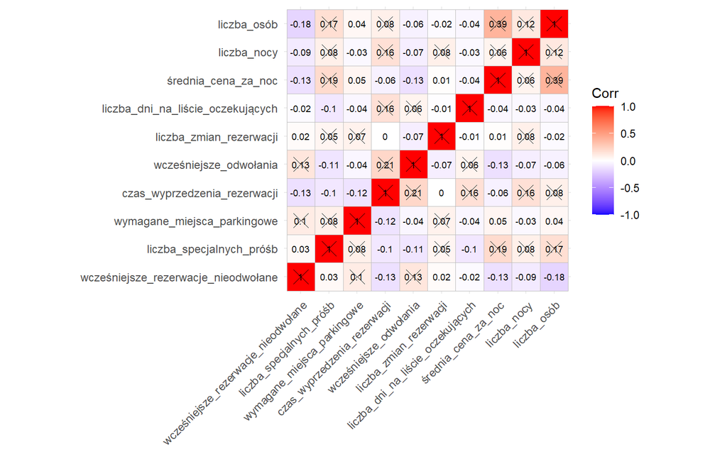

W przedstawionej **macierzy korelacji** można wydedukować, że istnieją pewne istotne korelacje między zmiennymi w zbiorze.

*2) Test Bartletta*

*H0: Macierz korelacji jest macierzą jednostkową (zmienne nie są skorelowane) - nie ma sensu wykonywać PCA*  
*H1: Macierz korelacji nie jest macierzą jednostkową (zmienne są skorelowane) - warto wykonywać redukcję wymiaru, analizę PCA*

| chisq | p.value | df |
| --- | --- | --- |
| 61079.862 | 0 | 45 |

Na podstawie **testu Bartletta** i p-value = 0 < alfa = 0,05 odrzucono H0 na rzecz HA stwierdzając, że macierz korelacji badanego zbioru danych ilościowych nie jest macierzą jednostkową, wobec czego warto wkonać redukcję wymiaru.

*3) Kryterum KMO (Keisera-Meyera-Olkina)*

| Zmienna | MSA |
| --- | --- |
| wcześniejsze_rezerwacje_nieodwołane | 0.573 |
| liczba_specjalnych_próśb | 0.67 |
| wymagane_miejsca_parkingowe | 0.611 |
| czas_wyprzedzenia_rezerwacji | 0.507 |
| wcześniejsze_odwołania | 0.545 |
| liczba_zmian_rezerwacji | 0.522 |
| liczba_dni_na_liście_oczekujących | 0.602 |
| średnia_cena_za_noc | 0.594 |
| liczba_nocy | 0.57 |
| liczba_osób | 0.576 |

Według ogólnie przyjmowanych progów dla **MSA**, tj.:

- ~0.5 - kryterium KMO nie roztrzyga, czy warto wykonywać PCA
- > 0.5 - warto wykonywać PCA
- < 0.5 - nie ma sensu wykonywać PCA

można uznać, że **warto** wykonać **analizę głównych składowych** dla analizowanych zmiennych, gdyż wynoszą one w większości **wiecej** lub **blisko 0,5**.  
Potwierdza to również Overall MSA* wynoszące **0,58**.

### 5.1.2. Określenie liczby składowych do redukcji

*1) Kryterium procentu wariancji*

|  | wartość własna | % wariancji | skumulowany % wariancji |
| --- | --- | --- | --- |
| Dim.1 | 1.714519243751259 | 17.14519243751585 | 17.14519243751585 |
| Dim.2 | 1.436698626000269 | 14.36698626000542 | 31.51217869752127 |
| Dim.3 | 1.094756618123344 | 10.94756618123552 | 42.45974487875679 |
| Dim.4 | 1.0664037682595 | 10.66403768259702 | 53.12378256135381 |
| Dim.5 | 0.982845789340151 | 9.828457893403378 | 62.95224045475719 |
| Dim.6 | 0.8736641757030034 | 8.736641757031695 | 71.6888822117889 |
| Dim.7 | 0.8563019105829912 | 8.56301910583154 | 80.25190131762042 |
| Dim.8 | 0.7521044183252684 | 7.521044183254114 | 87.77294550087454 |
| Dim.9 | 0.6467495109896225 | 6.467495109897454 | 94.240440610772 |
| Dim.10 | 0.5759559389226906 | 5.759559389228 | 100 |

*2) Kryterium Keisera*

*3) kryterium Catella*

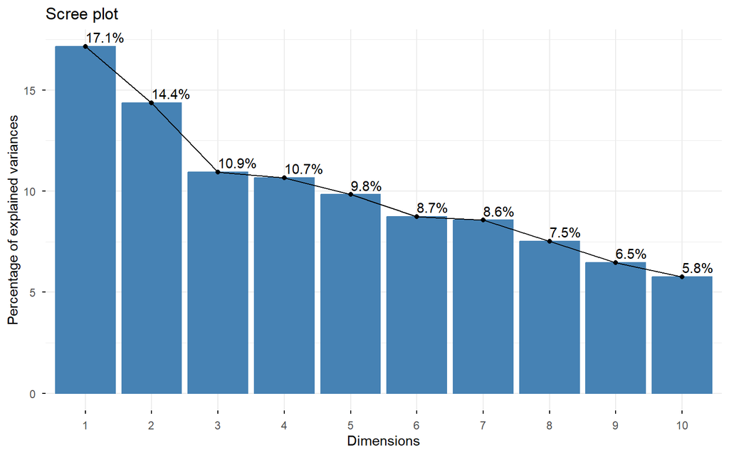

**Wykres osypiska** natomiast uwidocznił punkt przegięcia w 3 wymiarze - co za tym idzie, według *kryterium Catella* należy zastosować **2 wymiary**.

*Wniosek*

Na podstawie powyższej analizy uznano, że najbardziej dopasowaną liczbą wymiarów, do których należy zredukować analizowane zmienne to **3**.

### 5.1.3. Interpretacja wyników PCA

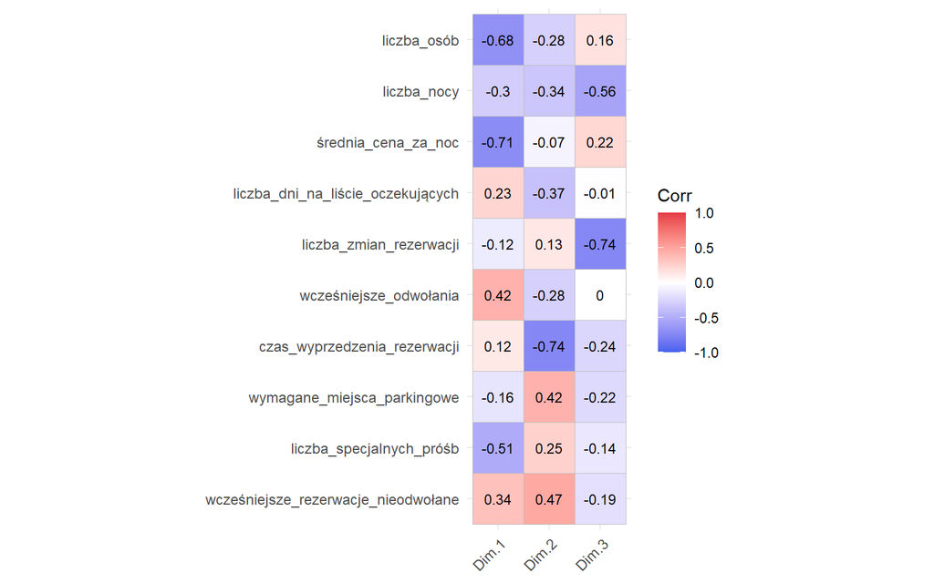

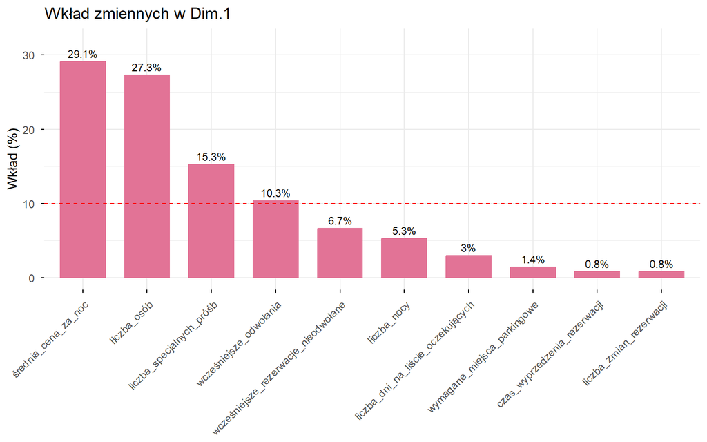

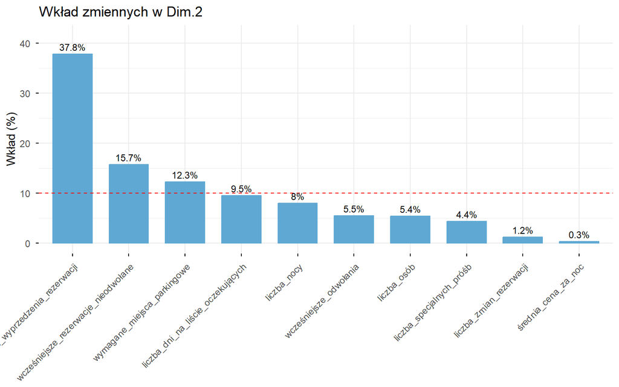

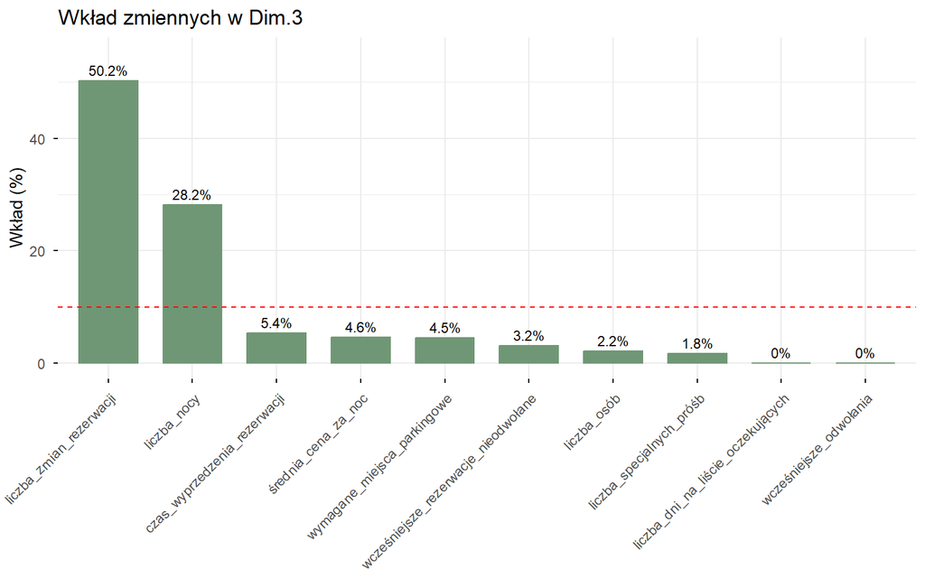

*Współczynniki korelacji* między oryginalnymi zmiennymi a nowo utworzonymi składowymi (**ładunki czynnikowe**) ukazują, które z nich najsilniej (a które najsłabiej) oddziaływały na daną składową główną. O znaczeniu zmiennej decydował jej procentowy wkład w daną składową (> 10%), natomiast znak ładunku określał kierunek zależności.

Najbardziej wpływające na utworzone wymiary zmienne to:

*Wymiar 2.*

- *czas_wyprzedzenia_rezerwacji* (37,8%, negatywny wpływ)
- *wcześniejsze_rezerwacje_nieodwołane* (15,7%, dodatni wpływ)
- *wymagane_miejsca_parkingowe* (12,3%, dodatni wpływ)

*Wymiar 3.*

- *liczba_zmian_rezerwacji* (50,2%, negatywny wpływ)
- *liczba_nocy* (28,2%, negatywny wpływ)

Wobec powyższego, zróżnicowanie rezerwacji hotelowych opisane zostało za pomocą trzech głównych cech:

- **profil cenowy i preferencje klientów** (pierwsza składowa główna)
- **planowanie rezerwacji** (druga składowa główna)
- **elastyczność i długość pobytu w hotelu** (trzecia składowa główna)

Korelację zmiennych oryginalnych z poszczególnymi składowymi głównymi przedstawia poniższa grafika.

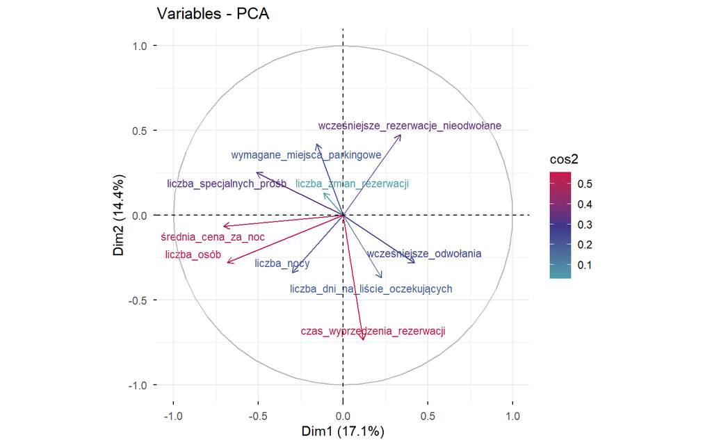

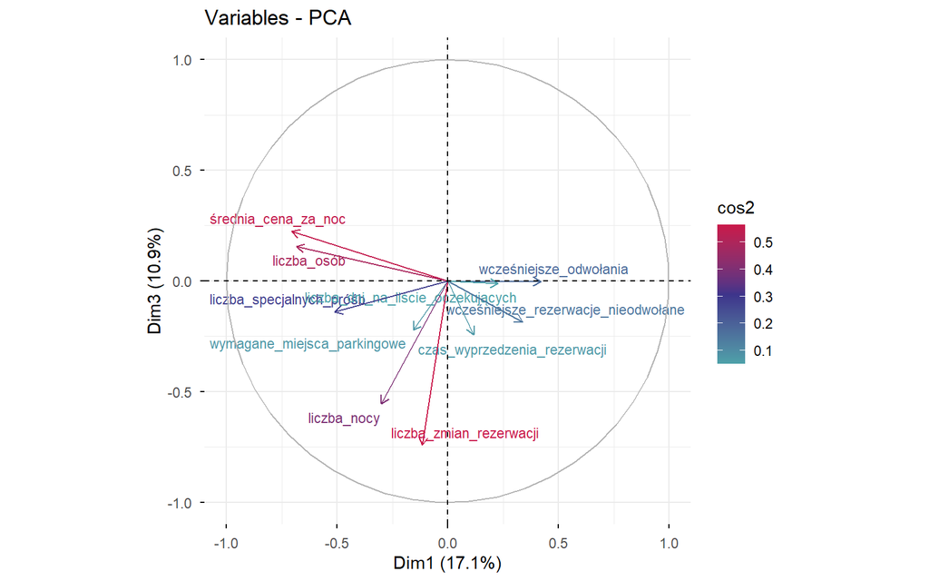

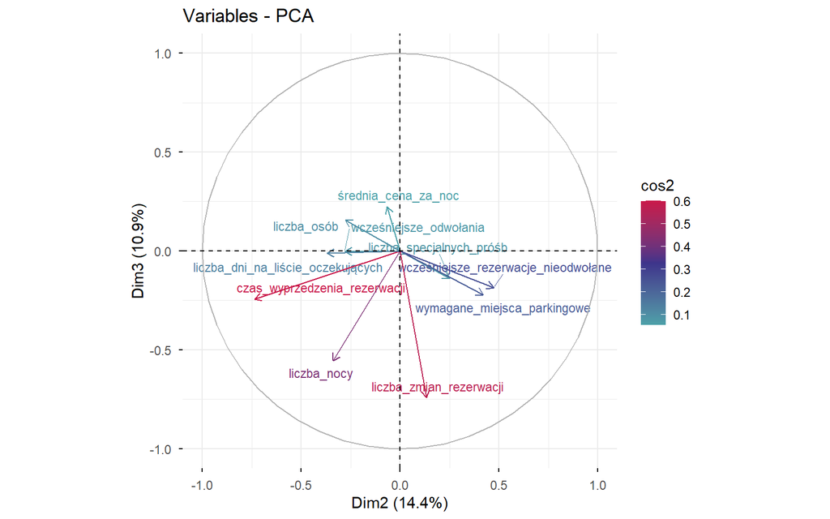

Z **wykresów korelacji zmeinnych PCA** wynika, że pierwsza główna składowa (*Dim1*) wraz z drugą (*Dim2*) łącznie wyjaśniają 31.5% całkowitej wariancji danych. Uwzględnienie trzeciej składowej (*Dim3*) zwiększa dodatkowo ten odsetek do 42.4%.

Na wykresach widoczne są wyraźne grupy zmiennych o zbliżonych kierunkach wektorów (np. w *Dim1-Dim2* para *wymagane_miejsca_parkingowe* i *liczba_specjalnych_próśb*, czy w *Dim2-Dim3* para *średnia_cena_za_noc* oraz *liczba_osób*), co wskazuje na ich dodatnią korelację, oraz zmienne skierowane przeciwnie (np. w *Dim1-Dim3* para *liczba_specjalnych_próśb* i *wcześniejsze_odwołania*), świadczące o ich ujemnym powiązaniu. Długość wektorów natomiast potwierdza, że zmienne wskazane wcześniej jako istotne dla poszczególnych wymiarów są właściwie przedstawiane w przestrzeni głównych składowych.

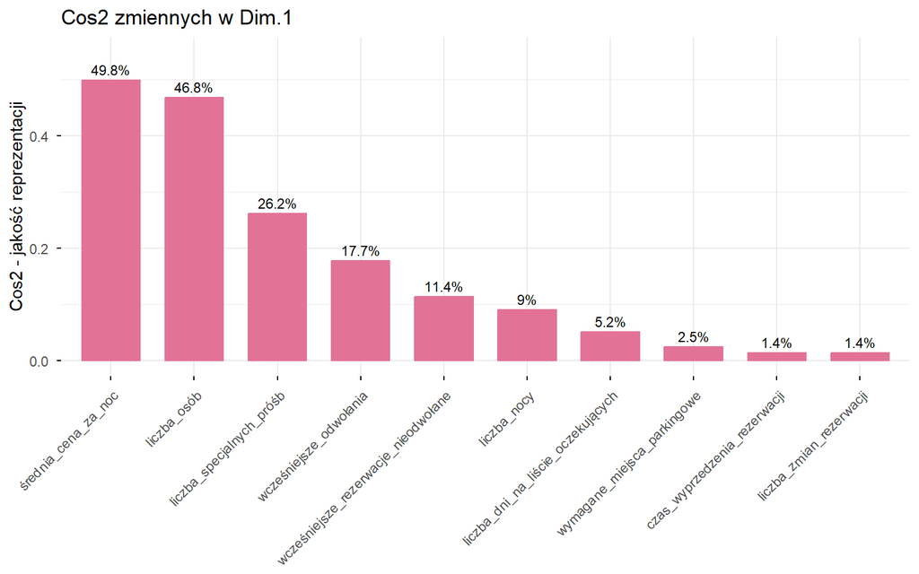

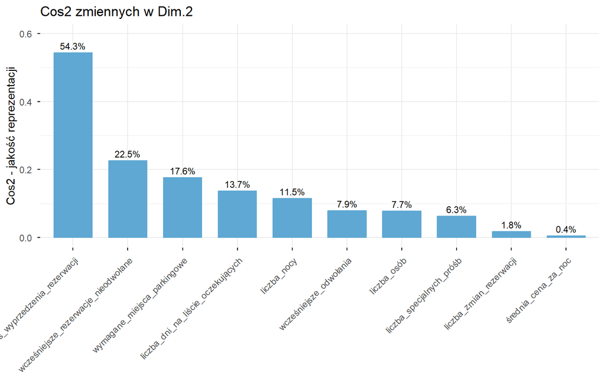

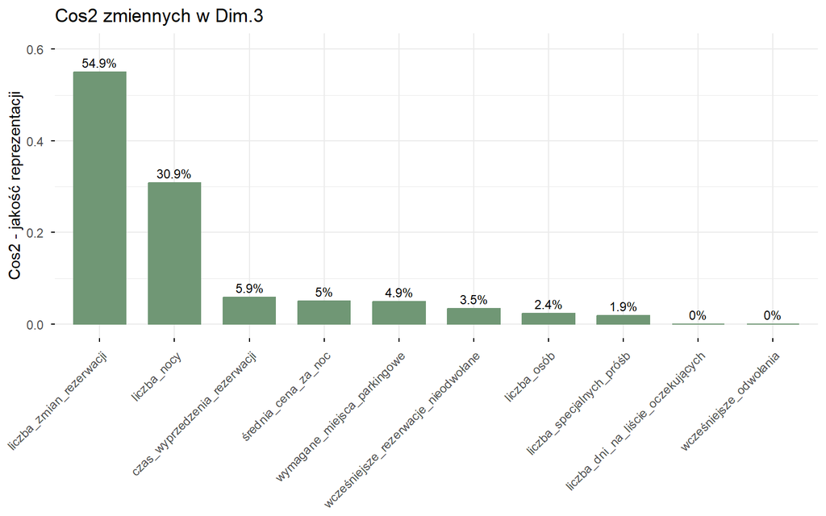

*Wymiar 1.* ponadto reprezentował w największej mierze zmienność *średniej ceny za noc* (49,8%) oraz *liczby osób* (46,8%).

*Wymiar 2.* odpowiadał za objaśnienie w 54,3% wariancji *czasu wprzedzenia rezerwacji*.

*Wymiar 3.* natomiast objaśnił głównie zmienność *liczby zmian rezerwacji* (w 54,9%) oraz *liczby nocy* (w 30,9%).

## 5.2 Analiza skupień

W kolejnym etapie przeprowadzono **analizę skupień** z wykorzystaniem metody podziału rozłącznego - metody *k-średnich (k-means)*. Polega ona na podziale zbioru obserwacji na określoną liczbę jednorodnych grup w taki sposób, aby obiekty wewnątrz klastrów były do siebie jak najbardziej podobne, natomiast różniły się maksymalnie od obiektów z pozostałych skupień. Dzieje się to za sprawą minimalizacji sumy kwadratów odległości obserwacji od centroidów klastrów, a co pozwala dokonać najbardziej skutecznego grupowania danych.

Wybór metody **k-średnich** jest uzasadniony przede wszystkim dużą liczebnością zbioru danych (ponad 119 tys. obserwacji), która sprawia, że zastosowanie klasycznych metod hierarchicznych (np. Warda) stają się zbyt złożone obliczeniowo, a co w przypadku **k-means** - jest możliwe do wykonania.

Dodatkowo, klasteryzacja została przeprowadzona na standaryzowanych zmiiennych ilościowych, co zapewniło ich porównywalność i zapobiegło dominacji zmiennych o większej skali.

Podobnie jak w przypadku analizy PCA - do przeprowadzenia analizy skupień użyto 10 zmiennych ze zbioru po obróbce, liczącego 22 zmiennych.

W kolejnych etapach dokonano:

1. **Określania optymalnej liczby skupień** przy pomocy metody łokcia, indeksu sylwetkowego oraz statystyki GAP,
2. **Właściwej analizy k-means** na pełnym zbiorze danych przy wybranej liczbie klastrów oraz analizy centrów skupień,
3. **Wizualizacji wyników segmentacji**, zarówno w przestrzeni zredukowanej do dwóch wymiarów, jak i na wykresach rozrzutu dla wybranych zmiennych, w celu oceny jakości i interpretowalności uzyskanych skupień.

### 5.2.1. Określanie optymalnej liczby skupień

*Z uwagi na bardzo dużą liczebność zbioru danych, obliczenia znajdujące się w tym kroku zostały przeprowadzone na losowej próbie obejmującej 5000 oraz 10 000 obserwacji. Sprwadzenie do prób było konieczne, ponieważ funkcje służące do wyznaczania miar jakości klasteryzacji wymagają tworzenia dużych macierzy odległości, których obliczenie dla pełnego zbioru przekraczało możliwości obliczeniowe programu R. Dodatkowo podjęto próbę wykorzystania pakietu NbClust, jednak nawet po ograniczeniu liczby obserwacji funkcja ta nie zadziałała poprawnie z uwagi na zbyt dużą złożoność obliczeń.*

*Nie użyto również głównych składowych wytypowanych przez analizę PCA, które zredukowały wymiar zbioru ze względu na fakt, że objaśniła ona mniej niż 50% wariancji zmienności danych.*

*1) Metoda łokciowa WSS (Elbow Method)*

Pierwsza z trzech obiektywnych metod wyboru liczby skupień jest **metoda łokciowa**, która polega na analizie zmiany sumy kwadratów odległości wewnątrz skupień *(WSS)* w zależności od liczby klastrów.  
Optymalną liczbę skupień wybiera się w miejscu, w którym dalsze zwiększanie liczby klastrów nie powoduje już istotnego zmniejszenia się wewnętrznego zróżnicowania danych *(WSS)*.

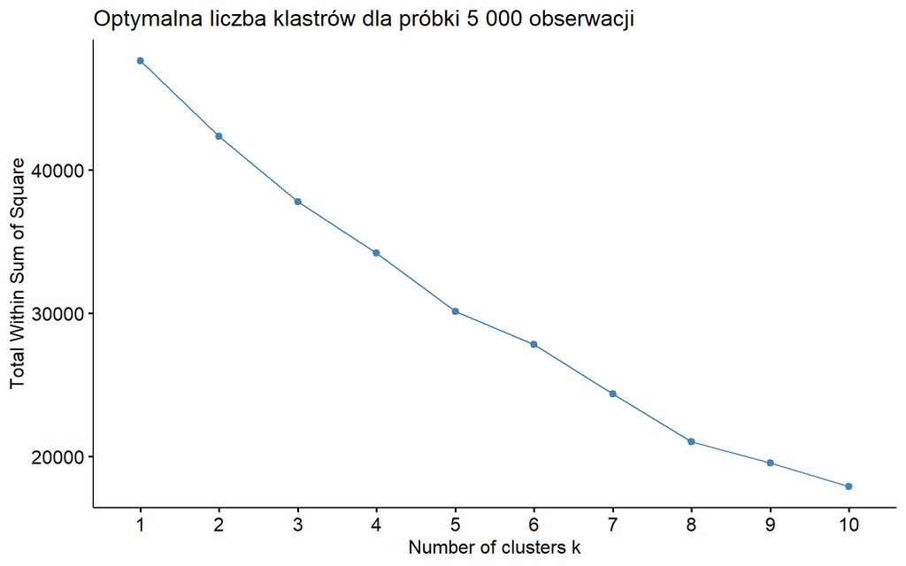

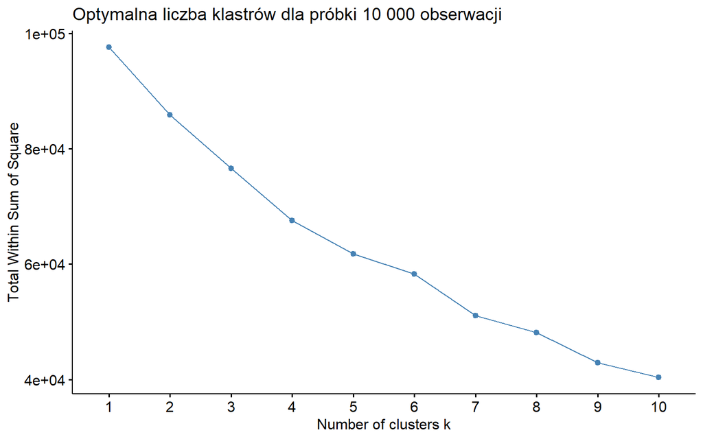

Analiza **wykresu łokcia**, na podstawie próbki liczącej 5 tys. oraz 10 tys. obserwacji nie wskazała okreslonej liczby klastrów, która byłaby najlepsza do grupowania wartości zmiennych ilosciowych w badanym zbiorze. Oba wykresy zostały wygładzone i nie uwidaczniają wyraźnego zaprzestania spadku wewnętrznego zróżnicowania danych.

Wobec tego, tę metodę wyznaczania optymalnej liczby skupień uznano za nieistotną i przystąpiono do dalszej analizy przy pomocy indeksu sylwetkowego oraz statystyki GAP.

*2) Indeks sylwetkowy (Silhouette Index)*

Drugą metodą jest **indeks sylwetkowy**, który mierzy jakość przypisania obserwacji do skupień, porównując podobieństwo obiektów wewnątrz klastra z ich odległością od innych klastrów.  
Optymalna liczba skupień odpowiada maksymalnej średniej wartości *indeksu sylwetki*.

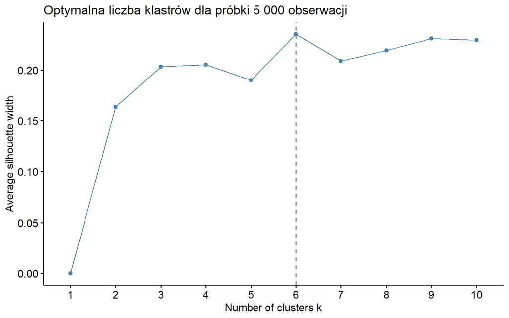

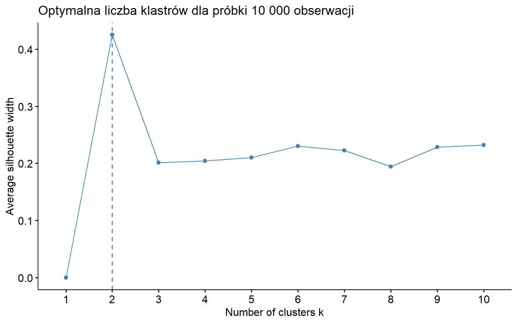

**Wykres skupiska** dla każdej z próbek wskazał różne wyniki efektywnego przypisania liczby skupisk dla analizowanych danych.

Dla próbki o liczebności 5 tys. obserwacji zostało wskazanych **6 klastrów** jako najbardziej optymalnych. Dla próbki z 10 tys. wartości były to natomiast **2 klastry**.

Wniosek z analizy *Silhouette Index* jest taki, że im większa jest liczebność próbki pobranej z oryginalnego zbioru danych *(hotel_std)*, tym mniejsza liczba klastrów jest uznawana za najbardziej efektywną i dopasowaną. Co za tym idzie - uznano, że **2-6 (ok. 4 klastry)* są najodpowiedniejszą liczbą skupisk do analizy k-means.

*1) Statystyka GAP (GAP Statistic)*

Ostatnią, trzecią metodą sprawdzania najodpowiedniejszej liczby klastrów do analizy skupień jest **statystyka GAP** porównująca jakość grupowania, która została uzyskana dla danych rzeczywistych z jakością grupowania dla danych losowych o tej samej strukturze.  
Optymalna liczba skupień to taka, dla której wartość *statystyki GAP* jest największa.

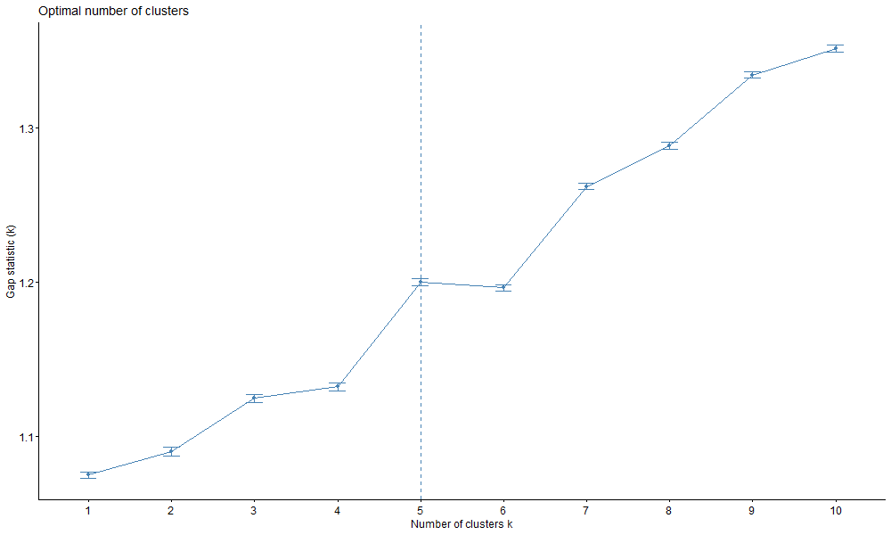

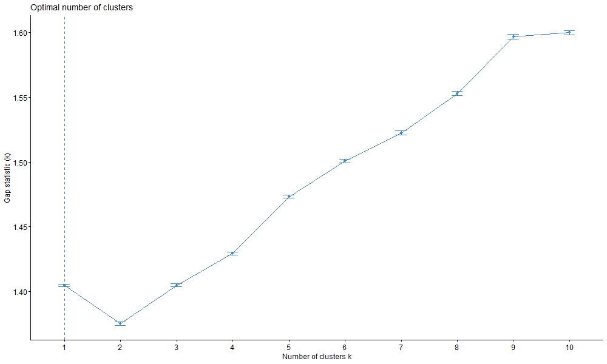

Wizualizacje prezentują wykres **statystyki GAP** dla próbki o liczebności 5 tys. oraz 10 tys. obserwacji, przy 5 inicjacjach algorytmu k-średnich oraz ograniczeniu liczby symulacji danych do oceny istotności do 10 (domyślnie 100).

Przez wzgląd na złożoność obliczeń przy wyznaczaniu *statystyki GAP*, a co za tym idzie - wydłużony czas oczekiwania na wyświetlanie wizualizacji dla próbki, zdecydowano się ująć wyniki słownie:

- *statystyka GAP* na próbce 10 tys. obserwacji, 5 inicjacjach oraz 10 symulacjach danych referencyjnych wskazuje **1 klaster** jako optymalny do użycia w dalszej analizie,
- *statystyka GAP* na próbce 10 tys. obserwacji, domyślnej, 1 liczbie inicjacji oraz 10 symulacjach wskazuje **1 klaster** ,
- *statystyka GAP* na próbce 5 tys. obserwacji, 5 inicjacjach oraz 10 symulacjach wskazuje **5 klastrów**,
- *statystyka GAP* na próbce 5 tys. obserwacji, 1 liczbie inicjacji oraz 10 symulacjach wskazuje **10+ klastrów**

Wnioskując - **statystyka GAP** w danym przypadku nie jest jednoznaczna we wskazaniu optymalnej liczby klastrów. Zauważyć jednak można, że podobnie jak w przypadku indeksu sylwetkowego - im liczniejsza była próbka pobrana z danych *(hotel_std)* i im większy był ustalony poziom interacji, tym statystyka wskazywała coraz mniejszą liczbę klastrów.  
Uznano więc, że liczebność grup, na podstawie *statsytyki GAP* powinna zawierać się między **2-5 klastrów (3 lub 4 skupiska)**.

*WNIOSEK*

Przeprowadzona przy użyciu powyższych metod analiza optymalnej liczby klastrów do dalszej analizy **k-średnich** nie przyniosła jednoznacznych rezultatów i wykazała niejdenorodne, trudne do interpretacji wyniki. Główną przyczyną tego problemu było przeprowadzone próbkowanie obserwacji (5 tys. i 10 tys.), ze względu na zbyt obciążeniową program analityczny liczebność zbioru danych (ponad 119 tys. obserwacji).

Wobec tego:  
- *metoda WSS* **nie wskazała żadnego** najefektywniejszego skupiska obserwacji, który byłby odpowiedni do dalszej analizy,  
- *indeks sylwetkowy* wskazał dwa potencjalnie istotne klastry: **2** i **6**,  
- *statystyka GAP* określiła **1** lub **5 klastrów** jako potencjalnie optymalne miejsca grupowanie się klastrów.

Przyjęto zatem liczbę **4 klastrów** za najbardziej dopasowaną do analizowanych danych.

### 5.2.2. Właściwa analiza *k-means*

W tym etapie przeprowadzono właściwe grupowanie obserwacji metodą **k-średnich** na pełnym zbiorze danych, przy założeniu podziału na 4 klastry. Algorytm został uruchomiony z wykorzystaniem 25 losowych inicjalizacji centroidów *(nstart = 25)*, co pozwoliło ograniczyć wpływ losowości na wynik algorytmu i zwiększyło wiarygodność wyników klasteryzacji.

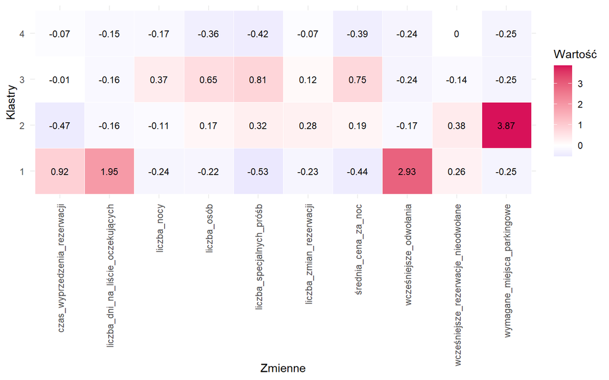

**Średnie wartości zmiennych** dla każdego klastra pokazują, jak poszczególne zmienne różnią się między grupami.  
Mapa ciepła pozowliła w prosty sposób zobczać zależności w klastrach, tzn. które zmienne są wyższe lub niższe w danym klastrze: bordowe pola oznaczają wartości powyżej średniej, niebieskie - poniżej średniej, a białe - wartości zbliżone do średniej.

*Klaster 1.*  
Klaster ten posiada wyraźnie wysokie wartości w zmiennych: *wcześniejsze_odwołania* (2,93), *liczba_dni_na_liście_oczekujących* (1,95) oraz *czas_wprzedzenia_rezerwacji* (0,92). można więc sądzić, że skupia on klientów, którzy planują swoje pobyty w hotelu z dużym wyprzedzeniem. Charakteryzują się oni dłuższym niż przeciętnie okresem czasu, jaki upływa od momentu dokonania rezerwacji pokoju do planowanego przyjazdu, a co się z tym wiąże - długim okresem przebywania na liście oczekujących, a także dużą liczbą wcześniejszych rezerwacji i ich odwołań. Sugeruje to, że są to osoby często rezerwujące noclegi, ale jednocześnie skłonne do zmiany planów.  
Pozostałe zmienne mają wartości średnie lub niższe od średniej, więc nie wyróżniają tej grupy.

*Klaster 3.*  
Klaster trzeci obejmuje rezerwacje potencjalnie liczniejsze i o wyższym standardzie. Charakteryzowni przez niego klienci podróżują w większych grupach *(liczba_osób: 0,65)*, składają więcej specjalnych próśb *(liczba_specjalnych_próśb: 0,81)* oraz decydują się na noclegi o wyższej cenie *(średnia_cena_za_noc: 0,75)*. Może to wskazywać na rodziny, grupy zorganizowane lub gości o podwyższonych oczekiwaniach co do jakości usług.

*Klaster 4.*  
Ostatni klaster reprezentuje najbardziej przeciętnych klientów, bez wyraźnych oczekiań ani szczególnych preferencji dotyczących warunków pobytu. Wszystkie analizowane zmienne przyjmują tu wartości bliskie średniej lub nieco niższe, co oznacza brak wyraźnych cech charakterystycznych. Klaster ten więc odzwierciedla zachowania standardowych klientów, stanowiąc punkt odniesienia dla pozostałych grup.

### 5.2.3. Wizualizacja wyników segmentacji

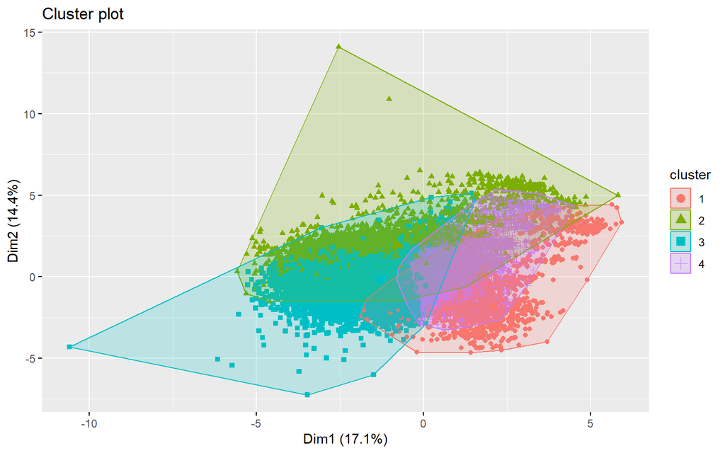

Wizualizacja wyników klasteryzacji z wykorzystaniem metody **k-średnich** dla 4 klastrów wskazuje na uzasadnioną segmentację obserwacji. Większość skupień tworzy widoczne grupy, odpowiadające poszczególnym klastrom, co sugeruje, że dane dają się racjonalnie segmentować. Chociaż niektóre klastry częściowo nakładają się na siebie, jest to spodziewany efekt, ponieważ wynika on z wielowymiarowego charakteru danych, gdzie część obserwacji posiada zbliżone wartości w różnych wymiarach. Widoczna jest jednak struktura klastrów, która potwierdza istnienie zróżnicowanych profili rezerwacji, a zastosowanie metody *k-means* można uznać za uzasadnione i efektywne w kontekście analizowanego zbioru.

**Klaster 2** *(zielony)* wykazuje największą rozpiętość i obejmuje obserwacje o bardziej zróżnicowanych profilach, podczas gdy **klaster 4** *(fioletowy)* tworzy stosunkowo zwartą grupę, co sugeruje spójność zachowań w tej grupie. **Klaster 1** *(czerwony)* i **klaster 3** *(niebieski)* również tworzą rozpoznawalne obszary, z lekkim nakładaniem się z innymi skupiskami, co może odzwierciedlać pewne wspólne cechy między grupami klientów.  
Wykres klasteryzacji zatem zachowuje wszystkie własności, które wytypowano przy omawianiu centroidów poszczególlnych z grup.

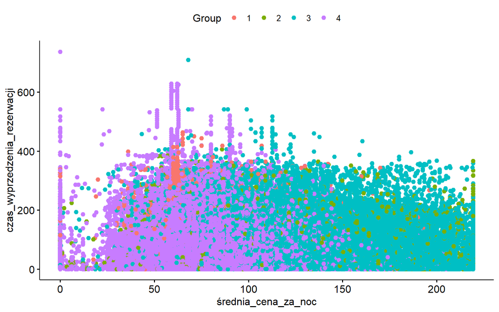

Do wizualizacji klastrów wybrano zmienne *średnia_cena_za_noc* oraz *czas_wyprzedzenia_rezerwacji*, które najlepiej różnicują hotele pod względem standardu i zachowań rezerwacyjnych klientów. Średnia cena odzwierciedla profil cenowy hotelu, natomiast czas wyprzedzenia pokazuje, w jaki sposób klienci planują pobyt.

Na wykresie można zauważyć, że pokoje o niższej średniej cenie (do 100 zł/noc) rezerwują głównie goście należący do **4. klastra**, czyli przeciętni klienci hotelu. Wśród nich znajdują się osoby reprezentujące zachowania **klastra 1.**, co sugeruje, że goście, którzy planują pobyt wcześniej, zapewniają sobie wybór hotelu i pokoju w niższej cenie.

# 6. Wnioski z analizy

Przeprowadzone testy wstępne, w tym *test Bartletta* i *kryterium KMO*, potwierdziły zasadność stosowania PCA, a analiza *procentu skumulowanej wariancji* oraz *wykres osypiska* wskazały trzy najbardziej znaczące wymiary. Interpretacja ładunków czynnikowych pozwoliła zidentyfikować zmienne o największym wpływie na poszczególne składowe, co ułatwiło zrozumienie, jakie aspekty rezerwacji odgrywają kluczową rolę w zachowaniach klientów. Wykresy korelacji zmiennych ze składowymi głównymi dodatkowo pokazały powiązania między zmiennymi i ich znaczenie w opisie całego zbioru.

Wyniki **analizy PCA** podsumowuje poniższa wizualizacja.

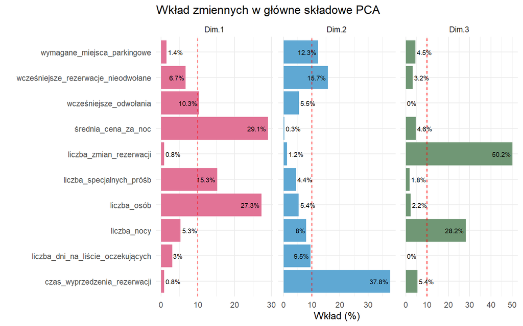

*Analiza skupień metodą k-średnich* umożliwiła podział obserwacji na **cztery grupy**, różniące się profilami klientów i ich preferencjami. Każdy klaster miał charakterystyczne cechy - od osób planujących pobyt z dużym wyprzedzeniem **(klaster 1.)**, przez gości wymagających konkretnych udogodnień **(klaster 2. i 3.)**, po klientów podróżujących w większych grupach **(klaster 3.)** i standardowych gości **(klaster 4.)**. *Analiza centrów klastrów* i wizualizacje wykazały, że grupy te są wyraźnie rozróżnialne i odzwierciedlają realne wzorce zachowań rezerwacyjnych.

**Analizę skupień** podsumowauje wizualizacja *wykresu radarowego*.

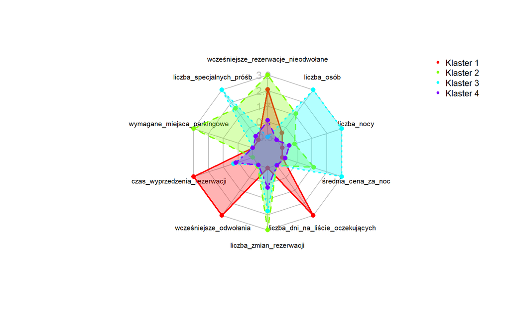

Połączenie wyników PCA z klasteryzacją pozwala zauważyć, że główne składowe dobrze odzwierciedlają czynniki, które różnicują poszczególne grupy klientów. Na przykład, pierwsza składowa, związana z profilem cenowym, koreluje z klastrami obejmującymi większe grupy i rezerwacje droższe, a druga składowa, opisująca planowanie rezerwacji, odpowiada grupom planującym pobyt z dużym wyprzedzeniem. Takie powiązanie pokazuje, że wybrane wymiary w PCA mają praktyczne znaczenie w segmentacji klientów.

Wnioski z obu analiz wskazują, że zbiór danych jest wielowymiarowy, ale jednocześnie uporządkowany, a obserwacje można efektywnie grupować według istotnych cech. Segmentacja klientów daje możliwość lepszego zrozumienia ich zachowań oraz planowania działań marketingowych lub ofert dopasowanych do potrzeb różnych grup. Zarówno PCA, jak i klasteryzacja, ułatwiają wyodrębnienie najważniejszych informacji i wspierają podejmowanie decyzji w oparciu o dane.

*Podsumowując, zastosowanie metod wielowymiarowych pozwoliło w sposób spójny i przejrzysty zredukować złożoność danych, a jednocześnie wyodrębnić charakterystyczne profile klientów hotelu. Obie metody – PCA i k-means – uzupełniają się wzajemnie, dając pełniejszy obraz zróżnicowania rezerwacji i preferencji klientów. Wyniki analiz mogą służyć do celów badawczych, ale także do praktycznych decyzji dotyczących zarządzania ofertą hotelową i planowania usług dopasowanych do różnych segmentów gości.*